# R Notebook

La methode des K-Moyennes encore appelée K-Means propose de choisir aléatoirement un point commle le barycentre de chaque groupepuis de le recalculer à chaque nouvel individu introduit dans le groupe. Cette technique est interessante car elle s’adapte lorsque nous injectons de nouveaux individus. K-means a la difference de la Classification ascendante hierarchique, ne fournis pas d’outil d’aide à la détection du nombre de classes sous R

Le nombre optimal de classes ici sera determiner par la methode de Calinksi-Harabasz

#Importation du dataframe

```r
data <- read.csv("C:/Users/Abraham_KINNIN/Desktop/KMeans Rstudio/supermarket_sales - Sheet1.csv", header = True, sep = ";")
```

```
Error: object 'True' not found
```

#Data mining C’est important de pouvoir comprendre les données que nous manipulons

```r
length(data) #longueur de la dataframe
dim(data) # la dimension
str(data) # La structure de la dataframe
nrow(data)
ncol(data)
```

[output not shown]

la fonction summary fait apparaitre une breve description statistique de nos données

```r
summary(data)
```

[output not shown]

En un premier temps je vais supprimer les valeurs manquantes et essayer de definir l’id comment valeur de colonne

```r
data <- na.omit(data)
```

```r
rownames(data)<- data$Invoice.ID
nrow(data)
```

Inspection des données est avec la fonction View

```r
View(data)
```

#Analyse exploratoire Observons la repartition de la categorie des consommateurs dans chaque ville

```r
tab
```

```
           Customer.type
City        Member Normal
  Mandalay     165    167
  Naypyitaw    169    159
  Yangon       167    173
```

[figure not shown]

```r
xtabs(~Product.line + Gender, data = kdata)
```

```
                        Gender
Product.line             Female Male
  Electronic accessories     84   86
  Fashion accessories        96   82
  Food and beverages         90   84
  Health and beauty          64   88
  Home and lifestyle         79   81
  Sports and travel          88   78
```

On peut rapidement deduire de ce tableau de contengence que les hommes consomment plus les accessoires electro les produits de beauté_santé, et de life style que les femmes on peut encore aller plus loin pour determiner les villes dans lesquelles ces produits sont plus consommées

```r
xtabs(~Product.line + City, data = kdata)
```

```
                        City
Product.line             Mandalay Naypyitaw Yangon
  Electronic accessories       55        55     60
  Fashion accessories          62        65     51
  Food and beverages           50        66     58
  Health and beauty            53        52     47
  Home and lifestyle           50        45     65
  Sports and travel            62        45     59
```

```r
fdata<- data[,c("Total","Cogs","gross.margin.percentage","gross.income","Rating")]
```

```
Error in `[.data.frame`(data, , c("Total", "Cogs", "gross.margin.percentage",  :
  undefined columns selected
```

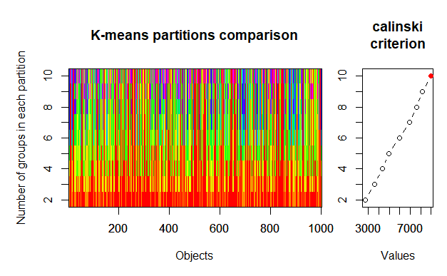

```r
if(!require("vegan")){
  install.packages("vegan")
}
library(vegan)
k.cal <- cascadeKM(fdata,2,10,
                   iter = 100,
                   criterion = "calinski")
plot(k.cal)
```

#LA methode elboww

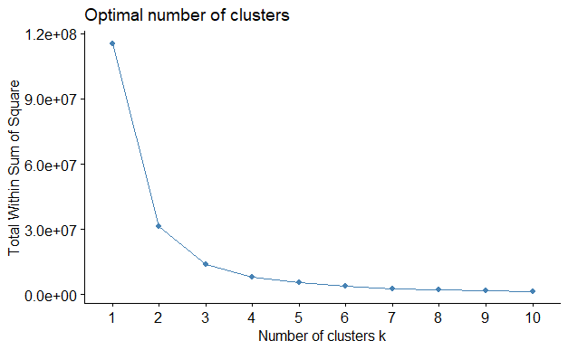

```r
library(factoextra)
library(ggplot2)
fviz_nbclust(fdata,kmeans,method = "wss")
```

Essayons l’ACP

```r
if(!require("ade4")){
  install.packages("ade4")
  library(ade4)
}
fdata.pca<- dudi.pca(fdata,center = TRUE,
                       scale = TRUE,
                       nf = 3,
                     scannf = FALSE)
```

Valeurs propres

```r
get_eig(fdata.pca)
```

[output not shown]

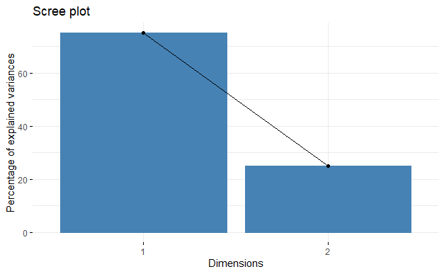

```r
library(factoextra)
fviz_screeplot(fdata.pca)
```

```r
library(FactoMineR)
dpca<-PCA(fdata,ncp = 3,graph = FALSE)
data.hcpc<-HCPC( dpca,
                graph = FALSE)
```

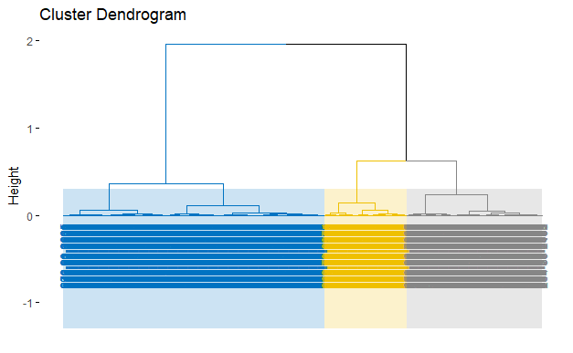

```r
fviz_dend(data.hcpc,cex = 0.7,palette = "jco",rect = TRUE,
          rect_fill = TRUE,rect_border = "jco",labels_track_height = 0.8)
```

[figure not shown]

```r
fviz_cluster(data.hcpc,repel = TRUE,show.clust.cent = TRUE,
             palette = "jco", ggtheme = theme_minimal(),
             main = "Map_Cluster")
```

L’ACP ne nous a pas trop aider on va devoir revoir nos variables